# Caderno de Exercícios

Introdução ao Tratamento de dados em R

Sergio Rivero

16 de maio, 2019

# 1 Exercícios

Este é o caderno de exercícios.

Este material vai ser ampliado na medida em que você for fazendo os exercícios em sala de aula.

O arquivo Rmd, testado e funcionando será utilizando para a avaliação da aprendizagem no final do curso.

Este arquivo deve ser entregue, ao final do curso para rivero@ufpa.br

## 1.1 Exercício Aula 1

### 1.1.1 Definindo o *Working directory*

**1) Baseado no que foi visto em sala de aula responda**

1. Em que diretório está o seu R agora ?

```r
getwd()
```

```
## [1] "/home/rivero/Dropbox/Workspace_Current/Projects/EmExec/Banpara/Cursos/git_curso/curso_intro_datascience/Apostilas/aux/Exercicios"
```

2. Altere seu diretório e repita o procedimento anterior
3. Quais elementos estão no seu ambiente de trabalho ?

```r
ls()
```

```
## [1] "x"
```

### 1.1.2 O R como calculadora

**Calcule as seguintes operações:**

1. $\frac{2}{36}$

```r
2/36
```

```
## [1] 0.05555556
```

2. $4 \times 8$
3. $5\times76$
4. $2^{9}$
5. $e^{2}$
6. $log7$
7. $ln{25}$
8. $\mid-10\mid$
9. $\sqrt{4489}$
10. $\frac{\sqrt{5} + 1}{3}$

### 1.1.3 Vetores e Matrizes

**3)Leia e responda as questões abaixo**

1. Crie e reproduza um vetor com os seguintes elementos: [laranja,manga,caju,uva], chame-o de “f”

```r
f <- c('laranja','manga','caju','uva')
f
```

```
## [1] "laranja" "manga"   "caju"    "uva"
```

2. Crie e reproduza um vetor com os seguintes elementos: [10,5,7,8], chame-o de “q”
3. Crie e reproduza um vetor com os seguintes elementos: [4,2,1,8], chame-o de “p”
4. Calcule e reproduza o produto dos vetores preco e quantidade e chame-o de “t”:

Mostrando o gráfico para $y = x^2$

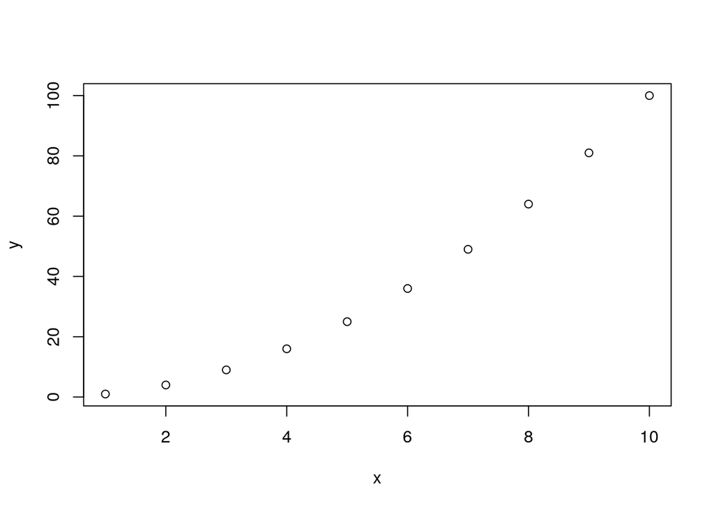

Comentário: neste gráfico acima vemos a linda forma que uma função quadrática pode ter mesmo sem ligar os pontos.

## 1.2 Exercício Aula 2

### 1.2.1 Vetores

1. Crie os seguintes vetores: temp = (26.1,26.7,22.7,16.8) , cidade = (João Pessoa, Manaus, Salvador, Curitiba), estado = (Paraíba, Amazonas, Bahia, Paraná)

```r
temp = c(26.1,26.7,22.7,16.8)
cidade = c('João Pessoa', 'Manaus', 'Salvador', 'Curitiba')
estado = c('Paraíba', 'Amazonas', 'Bahia', 'Paraná')
```

2. Mostre estes três vetores

```r
temp
```

```
## [1] 26.1 26.7 22.7 16.8
```

```r
cidade
```

```
## [1] "João Pessoa" "Manaus"      "Salvador"    "Curitiba"
```

```r
estado
```

```
## [1] "Paraíba"  "Amazonas" "Bahia"    "Paraná"
```

```r
t1 <- cbind(cidade, estado, temp)

temperaturas <- data.frame(t1)
```

Abaixo temos um exemplo de uma tabela com o Kable.

```r
kable(temperaturas, format = 'html', booktabs = TRUE)
```

| cidade | estado | temp |
| --- | --- | --- |
| João Pessoa | Paraíba | 26.1 |
| Manaus | Amazonas | 26.7 |
| Salvador | Bahia | 22.7 |
| Curitiba | Paraná | 16.8 |

Aqui utilizamos o xtable.

```r
tb1 <- xtable(temperaturas)

print.xtable(tb1, format = 'html')
```

[output not shown]

### 1.2.2 Listas

1. Agora crie uma lista através da função `list()` incluindo os três vetores criados anteriormente, chame-a de “lista”

```r
lista <- list(cidade, estado, temp)
```

```r
lista[2:3]
```

```
## [[1]]
## [1] "Paraíba"  "Amazonas" "Bahia"    "Paraná"
##
## [[2]]
## [1] 26.1 26.7 22.7 16.8
```

```r
class(lista[3])
```

```
## [1] "list"
```

```r
class(lista[[3]])
```

```
## [1] "numeric"
```

```r
lista[3][1]
```

```
## [[1]]
## [1] 26.1 26.7 22.7 16.8
```

3. Com apenas um comando, reproduza o dois últimos elementos da lista
4. Reproduza novamente o segundo elemento da lista, mas agora utilizando `[[]]`. Qual a diferença em relação ao item b), dica: use a função `class()`

### 1.2.3 Matrizes

```r
A = matrix(1:16,ncol = 4,nrow = 4)
B = matrix(11:26,ncol = 4,nrow = 4)


B+A
```

```
##      [,1] [,2] [,3] [,4]
## [1,]   12   20   28   36
## [2,]   14   22   30   38
## [3,]   16   24   32   40
## [4,]   18   26   34   42
```

B)Crie as seguintes matrizes:

$$m1 = \begin{pmatrix} 3 & 9 & -1 \\
4 & 2 & 6
\end{pmatrix}$$

$$m2 = \begin{pmatrix} 5 & 2 & 0 \\
9 & 3 & 4
\end{pmatrix}$$

2. Qual a soma dessas duas matrizes ?
3. Qual o resultado da subtração m1 - m2 ?
4. Transponha a matriz m1

### 1.2.4 Dataframes

Para esse exercício será necessário a utilização do pacote datasets, este contém uma grande quantidade de conjuntos de dados e será importante para as questões relacionadas a dataframes. Para ter mais informações, execute o comando: `library(help = "datasets")`.  
Uma dos data frames disponível nesse pacote é o “mtcars”, que descreve características de diferentes modelos de automóvel.

1. carregue os dados do data frame mtcars e obter informações sobre os dados.

```r
data("mtcars")
```

2. Verifique a classe de mtcars

```r
class(mtcars)
```

```
## [1] "data.frame"
```

3. Reproduza as seis primeiras e seis ultimas linhas do data frame
4. Agora reproduza as dez primeiras e as três últimas linhas do data frame
5. Verifique a estrutura do data frame
6. Quais são os nomes das colunas do date frame mtcars ?
7. Qual o número de linhas e colunas do data frame ?

```r
dim(mtcars)
```

```
## [1] 32 11
```

8. Reproduza apenas as seis primeiras colunas do data frame mtcars
9. Altere a classe da variável gear para integer

### 1.2.5 Importando dados para o R

1. Leia um arquivo csv na pasta “Dados”, que está no mesmo nível hierárquico da sua pasta “Exercicios”, importe o arquivo “PIB_BR_1996-2016.csv” e salve este arquivo na mesma pasta como um dataframe.

```r
PIB9616 <- read.csv(file = '../Dados/PIB_BR_1996-2016.csv', fileEncoding = "UTF-8")

save(PIB9616, file='../Dados/PIB9616.Rda')
```

2. Mostre as primeiras linhas do Dataframe “PIB9616”
3. Mostre a estrutura do Dataframe “PIB9616”
4. Altere os nomes das variaveis do dataframe para: c(‘Ano’, ‘PIBcorrente’,‘DeflatorPIB’,‘PopulacaoResidente’, ‘PIBpcCorrente’)
5. Leia o Arquivo ../Dados/PIB_BR_1996-2016.xlsx’ para o Dataframe “PIB9616excel”
6. Altere os nomes das variaveis do dataframe para: c(‘Ano’, ‘PIBcorrente’,‘DeflatorPIB’,‘PopulacaoResidente’, ‘PIBpcCorrente’)
7. Salve o Arquivo como “PIB9616excel.Rda”, na pasta “Data”
8. Salve uma versão csv do dataframe com o nome “PIB9616excel.csv”, na pasta “Data”

### 1.2.6 Importando Dados via API

1. Você vai precisar utilizar as bibliotecas “jsonlite”, “dplyr” e “lubridate”, procure na internet e diga para que estas 3 bibliotecas são utilizadas no R.

```r
library(jsonlite)
library(dplyr)
library(lubridate)
```

2. Baixe o arquivo do saldo de crédito de pessoas físicas para o Pará que está no sistema de dados abertos do BACEN, salvando o resultado em um dataframe

```r
download.file("http://api.bcb.gov.br/dados/serie/bcdata.sgs.14015/dados?formato=json&amp","Saldo_OpCreditoPF_PA")

Saldo_OpCreditoPF_PA <- fromJSON("Saldo_OpCreditoPF_PA")

save(Saldo_OpCreditoPF_PA, file="../Dados/Saldo_OpCreditoPF_PA.Rda")
```

3. Faça o Download do Arquivo de Saldo… do BCB de Concessões de crédito com recursos livres - Pessoas físicas - Crédito pessoal consignado para trabalhadores do setor público que pode ser encontrado em:

[Série Consignado Funcionários Públicos] (https://dadosabertos.bcb.gov.br/dataset/20669-concessoes-de-credito-com-recursos-livres---pessoas-fisicas---credito-pessoal-consignado-para)

Usando o api

4. Salve Esta série num Dataframe (“ConsignadoFuncPublicos.Rda”) na sua pasta Dados

# 2 Anotações

## 2.1 Anotações sobre o R

## 2.2 Anotações gerais